# Generalized linear regression: count regression

# 1 Setup

**R**

```r
install.packages("countreg", repos="http://R-Forge.R-project.org")
install.packages("topmodels", repos="http://R-Forge.R-project.org")
install.packages("performance")
install.packages("distributions3")
install.packages("modelsummary")
install.packages("marginaleffects")
install.packages("rstudioapi")
```

```r
library(MASS) ## glm.nb -- regresji ujemniej dwumianowej
library(countreg)
library(performance) ## określone miary jakosci
library(modelsummary)
library(boot)
library(marginaleffects)
```

Read in the dataset for the lecture and specify column classes (types).

```r
df <- read.csv("../data/polish-jvs.csv", colClasses = c("character", "factor", rep("character", 4), "numeric"))
head(df)
```

| id | woj | public | size | nace | nace_division | vacancies |
| --- | --- | --- | --- | --- | --- | --- |
| 27350 | 14 | 1 | Large | O | 84 | 2 |
| 26705 | 14 | 1 | Large | O | 84 | 1 |
| 257456 | 24 | 1 | Large | O | 84 | 2 |
| 183657 | 16 | 1 | Medium | O | 84 | 0 |
| 200042 | 18 | 1 | Medium | O | 84 | 0 |
| 26050 | 14 | 1 | Large | R | 91 | 4 |

**Python**

Load modules

```bash
!pip install statsmodels
```

```python
import pandas as pd
import numpy as np
import statsmodels.api as sm
import statsmodels.formula.api as smf
```

Read in the dataset for the lecture and specify column classes (types).

```python
df = pd.read_csv("../data/polish-jvs.csv", dtype={"id": np.int64, "woj":str, "public":str,"size": str, "nace_division": str, "nace": str})
df.head()
```

```
       id woj public    size nace nace_division  vacancies
0   27350  14      1   Large    O            84          2
1   26705  14      1   Large    O            84          1
2  257456  24      1   Large    O            84          2
3  183657  16      1  Medium    O            84          0
4  200042  18      1  Medium    O            84          0
```

**Julia**

```julia
using Pkg
Pkg.add(["Effects", "StatsBase", "CSV", "CategoricalArrays", "GLM"])
```

Load packages

```julia
using Effects
using StatsBase
using CSV
using CategoricalArrays
using GLM
using Statistics
using DataFrames
```

Read in the dataset for the lecture and specify column classes (types).

```julia
df=CSV.read("../data/polish-jvs.csv", DataFrame,
            types = Dict(:id => Int64, :woj=> String, :public=> String,
                         :size => String, :nace_division => String, :nace => String));
first(df, 5)
```

# 2 Poisson

**R**

```r
mean(df$vacancies)
```

```
[1] 1.016232
```

```r
var(df$vacancies)
```

```
[1] 95.91924
```

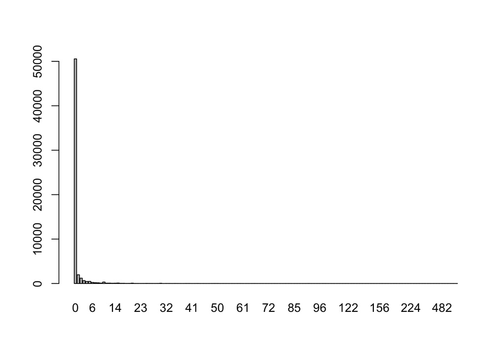

```r
barplot(table(df$vacancies))
```

```r
summary(df$vacancies)
```

```
   Min. 1st Qu.  Median    Mean 3rd Qu.    Max.
  0.000   0.000   0.000   1.016   0.000 892.000
```

```r
m1 <- glm(vacancies ~ size + public + woj, data = df, family = poisson())
summary(m1)
```

```
Call:
glm(formula = vacancies ~ size + public + woj, family = poisson(),
    data = df)

Coefficients:
             Estimate Std. Error  z value Pr(>|z|)
(Intercept)  0.993115   0.014215   69.863  < 2e-16 ***
sizeMedium  -1.998674   0.016602 -120.386  < 2e-16 ***
sizeSmall   -3.364458   0.031266 -107.606  < 2e-16 ***
public1     -0.582193   0.009372  -62.122  < 2e-16 ***
woj04       -0.769132   0.027730  -27.737  < 2e-16 ***
woj06       -1.035630   0.033123  -31.266  < 2e-16 ***
woj08       -0.487152   0.030963  -15.734  < 2e-16 ***
woj10       -0.394505   0.023228  -16.984  < 2e-16 ***
woj12        0.118382   0.018860    6.277 3.46e-10 ***
woj14        0.704005   0.015708   44.819  < 2e-16 ***
woj16       -0.634812   0.033478  -18.962  < 2e-16 ***
woj18       -0.991023   0.030691  -32.290  < 2e-16 ***
woj20       -0.839525   0.035229  -23.831  < 2e-16 ***
woj22       -0.354411   0.022418  -15.809  < 2e-16 ***
woj24       -0.298501   0.019340  -15.434  < 2e-16 ***
woj26       -0.926980   0.036476  -25.414  < 2e-16 ***
woj28       -0.903407   0.033691  -26.815  < 2e-16 ***
woj30       -0.188384   0.019795   -9.517  < 2e-16 ***
woj32       -0.348939   0.025561  -13.651  < 2e-16 ***
---
Signif. codes:  0 '***' 0.001 '**' 0.01 '*' 0.05 '.' 0.1 ' ' 1

(Dispersion parameter for poisson family taken to be 1)

    Null deviance: 380377  on 57479  degrees of freedom
Residual deviance: 306152  on 57461  degrees of freedom
AIC: 328100

Number of Fisher Scoring iterations: 8
```

```r
exp(coef(m1))
```

```
(Intercept)  sizeMedium   sizeSmall     public1       woj04       woj06
 2.69962981  0.13551482  0.03458076  0.55867178  0.46341499  0.35500262
      woj08       woj10       woj12       woj14       woj16       woj18
 0.61437363  0.67401336  1.12567354  2.02183306  0.53003494  0.37119695
      woj20       woj22       woj24       woj26       woj28       woj30
 0.43191546  0.70158662  0.74192925  0.39574693  0.40518703  0.82829672
      woj32
 0.70543585
```

Marginal effects

```r
avg_slopes(m1)
```

```
   Term       Contrast Estimate Std. Error       z Pr(>|z|)     S  2.5 % 97.5 %
 public 1 - 0            -0.544    0.00816  -66.70   <0.001   Inf -0.560 -0.528
 size   Medium - Large   -1.694    0.00957 -176.97   <0.001   Inf -1.713 -1.675
 size   Small - Large    -1.892    0.00882 -214.37   <0.001   Inf -1.909 -1.874
 woj    04 - 02          -0.627    0.02078  -30.15   <0.001 660.8 -0.667 -0.586
 woj    06 - 02          -0.753    0.02046  -36.80   <0.001 982.6 -0.793 -0.713
 woj    08 - 02          -0.450    0.02564  -17.56   <0.001 226.9 -0.501 -0.400
 woj    10 - 02          -0.381    0.02186  -17.41   <0.001 223.1 -0.423 -0.338
 woj    12 - 02           0.147    0.02333    6.29   <0.001  31.6  0.101  0.192
 woj    14 - 02           1.193    0.02372   50.30   <0.001   Inf  1.147  1.240
 woj    16 - 02          -0.549    0.02487  -22.06   <0.001 355.9 -0.598 -0.500
 woj    18 - 02          -0.734    0.02010  -36.53   <0.001 967.9 -0.774 -0.695
 woj    20 - 02          -0.663    0.02302  -28.81   <0.001 604.1 -0.708 -0.618
 woj    22 - 02          -0.348    0.02170  -16.06   <0.001 190.3 -0.391 -0.306
 woj    24 - 02          -0.301    0.01998  -15.08   <0.001 168.4 -0.340 -0.262
 woj    26 - 02          -0.706    0.02250  -31.36   <0.001 714.6 -0.750 -0.661
 woj    28 - 02          -0.695    0.02178  -31.89   <0.001 739.0 -0.737 -0.652
 woj    30 - 02          -0.200    0.02119   -9.46   <0.001  68.1 -0.242 -0.159
 woj    32 - 02          -0.344    0.02399  -14.34   <0.001 152.4 -0.391 -0.297

Type:  response
```

Quasi-poisson regression (aka NB type 1)

```r
m2 <- glm(vacancies ~ size + public + woj, data = df, family = quasipoisson())
```

```r
summary(m2)
```

```
Call:
glm(formula = vacancies ~ size + public + woj, family = quasipoisson(),
    data = df)

Coefficients:
            Estimate Std. Error t value Pr(>|t|)
(Intercept)  0.99311    0.08770  11.324  < 2e-16 ***
sizeMedium  -1.99867    0.10243 -19.513  < 2e-16 ***
sizeSmall   -3.36446    0.19290 -17.442  < 2e-16 ***
public1     -0.58219    0.05782 -10.069  < 2e-16 ***
woj04       -0.76913    0.17108  -4.496 6.94e-06 ***
woj06       -1.03563    0.20435  -5.068 4.04e-07 ***
woj08       -0.48715    0.19102  -2.550 0.010767 *
woj10       -0.39451    0.14330  -2.753 0.005908 **
woj12        0.11838    0.11636   1.017 0.308972
woj14        0.70400    0.09691   7.265 3.78e-13 ***
woj16       -0.63481    0.20654  -3.074 0.002116 **
woj18       -0.99102    0.18935  -5.234 1.67e-07 ***
woj20       -0.83953    0.21734  -3.863 0.000112 ***
woj22       -0.35441    0.13830  -2.563 0.010393 *
woj24       -0.29850    0.11932  -2.502 0.012362 *
woj26       -0.92698    0.22503  -4.119 3.81e-05 ***
woj28       -0.90341    0.20785  -4.346 1.39e-05 ***
woj30       -0.18838    0.12212  -1.543 0.122944
woj32       -0.34894    0.15769  -2.213 0.026918 *
---
Signif. codes:  0 '***' 0.001 '**' 0.01 '*' 0.05 '.' 0.1 ' ' 1

(Dispersion parameter for quasipoisson family taken to be 38.06172)

    Null deviance: 380377  on 57479  degrees of freedom
Residual deviance: 306152  on 57461  degrees of freedom
AIC: NA

Number of Fisher Scoring iterations: 8
```

Dispersion parameter $\phi = 38.06172$ which can be calculated based on `m1` model:

```r
pearson_r <- residuals(m1, type = "pearson")
sum(pearson_r^2)/m1$df.residual
```

```
[1] 38.06172
```

```r
summary(summary(m2)$coef[,2]/summary(m1)$coef[,2])
```

```
   Min. 1st Qu.  Median    Mean 3rd Qu.    Max.
  6.169   6.169   6.169   6.169   6.169   6.169
```

Now, compare estimated parameters and their standard errors.

```r
modelsummary(list("Poisson"=m1, "QPoisson"=m2))
```

|  | Poisson | QPoisson |
| --- | --- | --- |
| (Intercept) | 0.993 | 0.993 |
|  | (0.014) | (0.088) |
| sizeMedium | -1.999 | -1.999 |
|  | (0.017) | (0.102) |
| sizeSmall | -3.364 | -3.364 |
|  | (0.031) | (0.193) |
| public1 | -0.582 | -0.582 |
|  | (0.009) | (0.058) |
| woj04 | -0.769 | -0.769 |
|  | (0.028) | (0.171) |
| woj06 | -1.036 | -1.036 |
|  | (0.033) | (0.204) |
| woj08 | -0.487 | -0.487 |
|  | (0.031) | (0.191) |
| woj10 | -0.395 | -0.395 |
|  | (0.023) | (0.143) |
| woj12 | 0.118 | 0.118 |
|  | (0.019) | (0.116) |
| woj14 | 0.704 | 0.704 |
|  | (0.016) | (0.097) |
| woj16 | -0.635 | -0.635 |
|  | (0.033) | (0.207) |
| woj18 | -0.991 | -0.991 |
|  | (0.031) | (0.189) |
| woj20 | -0.840 | -0.840 |
|  | (0.035) | (0.217) |
| woj22 | -0.354 | -0.354 |
|  | (0.022) | (0.138) |
| woj24 | -0.299 | -0.299 |
|  | (0.019) | (0.119) |
| woj26 | -0.927 | -0.927 |
|  | (0.036) | (0.225) |
| woj28 | -0.903 | -0.903 |
|  | (0.034) | (0.208) |
| woj30 | -0.188 | -0.188 |
|  | (0.020) | (0.122) |
| woj32 | -0.349 | -0.349 |
|  | (0.026) | (0.158) |
| Num.Obs. | 57480 | 57480 |
| AIC | 328099.9 |  |
| BIC | 328270.1 |  |
| Log.Lik. | -164030.939 |  |
| F | 2707.731 | 71.141 |
| RMSE | 9.71 | 9.71 |

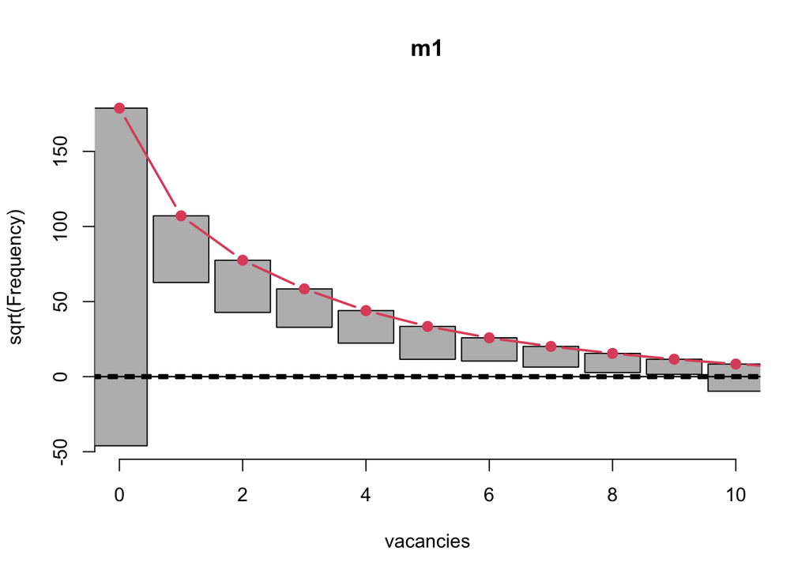

```r
topmodels::rootogram(m1, plot = "base", xlim = c(0,10))
```

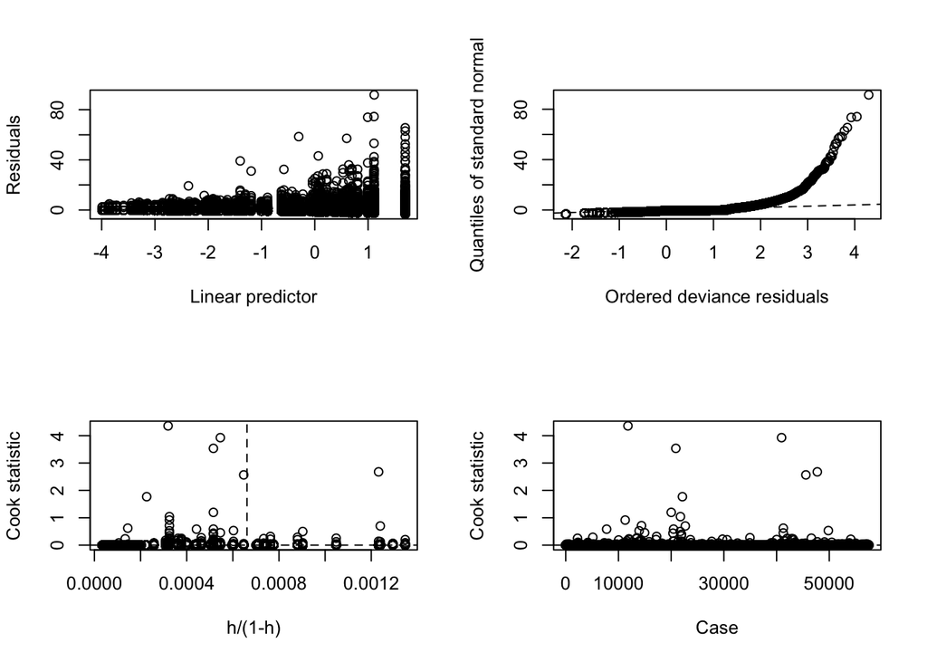

```r
glm.diag.plots(m1)
```

```r
exp(coef(m1))
```

```
(Intercept)  sizeMedium   sizeSmall     public1       woj04       woj06
 2.69962981  0.13551482  0.03458076  0.55867178  0.46341499  0.35500262
      woj08       woj10       woj12       woj14       woj16       woj18
 0.61437363  0.67401336  1.12567354  2.02183306  0.53003494  0.37119695
      woj20       woj22       woj24       woj26       woj28       woj30
 0.43191546  0.70158662  0.74192925  0.39574693  0.40518703  0.82829672
      woj32
 0.70543585
```

Interpretation

- Medium vs. Large Companies
  - $\exp(\hat{\beta})$ `= 0.136`: The expected vacancies for Medium-sized companies is approximately 13.6% of that for Large companies, holding all other variables constant.
  - `AME = -1.694`: Medium-sized companies have, on average, 1.694 fewer vacancies compared to Large companies, holding all other factors constant.
- Mazowieckie (14) vs. Dolnośląskie (02):
  - $\exp(\hat{\beta})$ `= 2.022`: The expected count in Mazowieckie province is approximately 2.02 times higher (or 102.2% higher) than in Dolnośląskie province, holding all other variables constant.
  - `AME = 1.193`: The expected vacancies in Mazowieckie province is, on average, 1.193 higher than in Dolnośląskie province, holding all other factors constant.

**Python**

```python
m1 = smf.glm(formula="vacancies ~ size + public + woj", data=df, family=sm.families.Poisson()).fit()
print(m1.summary())
```

```
                 Generalized Linear Model Regression Results
==============================================================================
Dep. Variable:              vacancies   No. Observations:                57480
Model:                            GLM   Df Residuals:                    57461
Model Family:                 Poisson   Df Model:                           18
Link Function:                    Log   Scale:                          1.0000
Method:                          IRLS   Log-Likelihood:            -1.6403e+05
Date:                Sun, 11 May 2025   Deviance:                   3.0615e+05
Time:                        20:24:30   Pearson chi2:                 2.19e+06
No. Iterations:                     7   Pseudo R-squ. (CS):             0.7251
Covariance Type:            nonrobust
==================================================================================
                     coef    std err          z      P>|z|      [0.025      0.975]
----------------------------------------------------------------------------------
Intercept          0.9931      0.014     69.863      0.000       0.965       1.021
size[T.Medium]    -1.9987      0.017   -120.386      0.000      -2.031      -1.966
size[T.Small]     -3.3645      0.031   -107.606      0.000      -3.426      -3.303
public[T.1]       -0.5822      0.009    -62.122      0.000      -0.601      -0.564
woj[T.04]         -0.7691      0.028    -27.737      0.000      -0.823      -0.715
woj[T.06]         -1.0356      0.033    -31.266      0.000      -1.101      -0.971
woj[T.08]         -0.4872      0.031    -15.734      0.000      -0.548      -0.426
woj[T.10]         -0.3945      0.023    -16.984      0.000      -0.440      -0.349
woj[T.12]          0.1184      0.019      6.277      0.000       0.081       0.155
woj[T.14]          0.7040      0.016     44.819      0.000       0.673       0.735
woj[T.16]         -0.6348      0.033    -18.962      0.000      -0.700      -0.569
woj[T.18]         -0.9910      0.031    -32.290      0.000      -1.051      -0.931
woj[T.20]         -0.8395      0.035    -23.831      0.000      -0.909      -0.770
woj[T.22]         -0.3544      0.022    -15.809      0.000      -0.398      -0.310
woj[T.24]         -0.2985      0.019    -15.434      0.000      -0.336      -0.261
woj[T.26]         -0.9270      0.036    -25.414      0.000      -0.998      -0.855
woj[T.28]         -0.9034      0.034    -26.815      0.000      -0.969      -0.837
woj[T.30]         -0.1884      0.020     -9.517      0.000      -0.227      -0.150
woj[T.32]         -0.3489      0.026    -13.651      0.000      -0.399      -0.299
==================================================================================
```

**Julia**

# 3 Negative binomial

**R**

```r
m3 <- glm.nb(vacancies ~ size + public + woj, data = df)
m3
```

```
Call:  glm.nb(formula = vacancies ~ size + public + woj, data = df,
    init.theta = 0.05780092749, link = log)

Coefficients:
(Intercept)   sizeMedium    sizeSmall      public1        woj04        woj06
    0.94376     -1.94750     -3.20119     -0.58067     -0.68160     -1.01381
      woj08        woj10        woj12        woj14        woj16        woj18
   -0.25026     -0.23589     -0.03609      0.58852     -0.53552     -0.89133
      woj20        woj22        woj24        woj26        woj28        woj30
   -0.70398     -0.21454     -0.19206     -0.76538     -0.81302     -0.20063
      woj32
   -0.30772

Degrees of Freedom: 57479 Total (i.e. Null);  57461 Residual
Null Deviance:      21780
Residual Deviance: 16950    AIC: 76660
```

```r
summary(m3)
```

```
Call:
glm.nb(formula = vacancies ~ size + public + woj, data = df,
    init.theta = 0.05780092749, link = log)

Coefficients:
            Estimate Std. Error z value Pr(>|z|)
(Intercept)  0.94376    0.07248  13.021  < 2e-16 ***
sizeMedium  -1.94750    0.04514 -43.145  < 2e-16 ***
sizeSmall   -3.20119    0.05596 -57.207  < 2e-16 ***
public1     -0.58067    0.04127 -14.070  < 2e-16 ***
woj04       -0.68160    0.10910  -6.247 4.18e-10 ***
woj06       -1.01381    0.11435  -8.866  < 2e-16 ***
woj08       -0.25026    0.12215  -2.049  0.04047 *
woj10       -0.23589    0.10253  -2.301  0.02140 *
woj12       -0.03609    0.09549  -0.378  0.70545
woj14        0.58852    0.08541   6.890 5.57e-12 ***
woj16       -0.53552    0.12631  -4.240 2.24e-05 ***
woj18       -0.89133    0.10974  -8.122 4.57e-16 ***
woj20       -0.70398    0.12555  -5.607 2.06e-08 ***
woj22       -0.21454    0.10095  -2.125  0.03357 *
woj24       -0.19206    0.09016  -2.130  0.03316 *
woj26       -0.76538    0.12551  -6.098 1.07e-09 ***
woj28       -0.81302    0.11841  -6.866 6.59e-12 ***
woj30       -0.20063    0.09342  -2.148  0.03174 *
woj32       -0.30772    0.10971  -2.805  0.00503 **
---
Signif. codes:  0 '***' 0.001 '**' 0.01 '*' 0.05 '.' 0.1 ' ' 1

(Dispersion parameter for Negative Binomial(0.0578) family taken to be 1)

    Null deviance: 21785  on 57479  degrees of freedom
Residual deviance: 16951  on 57461  degrees of freedom
AIC: 76663

Number of Fisher Scoring iterations: 1

              Theta:  0.057801
          Std. Err.:  0.000888

 2 x log-likelihood:  -76623.429000
```

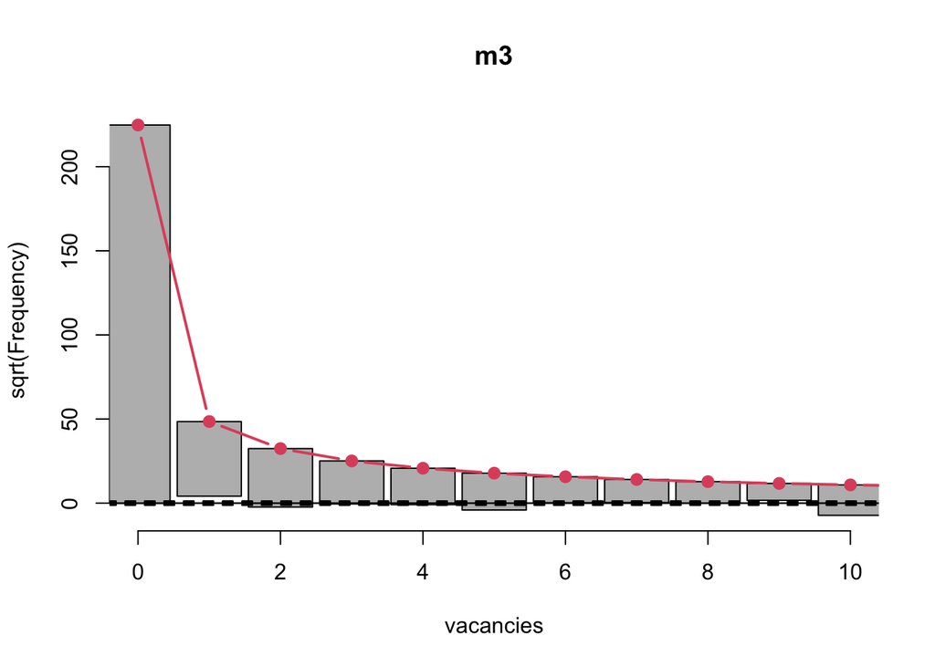

```r
topmodels::rootogram(m3, plot = "base", xlim = c(0,10))
```

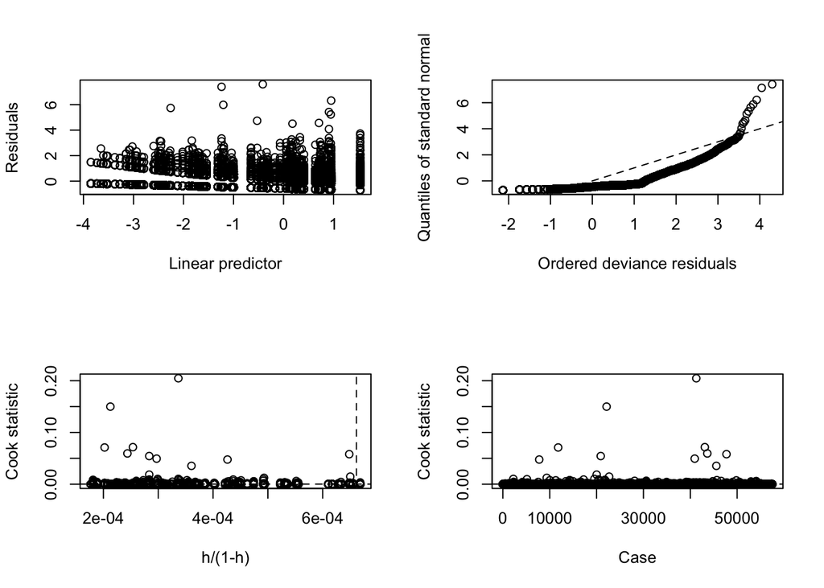

```r
glm.diag.plots(m3)
```

```r
exp(coef(m3))
```

```
(Intercept)  sizeMedium   sizeSmall     public1       woj04       woj06
 2.56961427  0.14263050  0.04071372  0.55952609  0.50580741  0.36283542
      woj08       woj10       woj12       woj14       woj16       woj18
 0.77859559  0.78986618  0.96454931  1.80131333  0.58536393  0.41010863
      woj20       woj22       woj24       woj26       woj28       woj30
 0.49461355  0.80691455  0.82525626  0.46515715  0.44351781  0.81821525
      woj32
 0.73512413
```

**Python**

```python
m3 = smf.glm(formula="vacancies ~ size + public + woj", data=df, family=sm.families.NegativeBinomial()).fit()
print(m3.summary())
```

```
                 Generalized Linear Model Regression Results
==============================================================================
Dep. Variable:              vacancies   No. Observations:                57480
Model:                            GLM   Df Residuals:                    57461
Model Family:        NegativeBinomial   Df Model:                           18
Link Function:                    Log   Scale:                          1.0000
Method:                          IRLS   Log-Likelihood:                -61974.
Date:                Sun, 11 May 2025   Deviance:                       90162.
Time:                        20:24:48   Pearson chi2:                 8.23e+05
No. Iterations:                    10   Pseudo R-squ. (CS):             0.4720
Covariance Type:            nonrobust
==================================================================================
                     coef    std err          z      P>|z|      [0.025      0.975]
----------------------------------------------------------------------------------
Intercept          0.9669      0.025     39.339      0.000       0.919       1.015
size[T.Medium]    -1.9759      0.020    -99.656      0.000      -2.015      -1.937
size[T.Small]     -3.3342      0.033    -99.620      0.000      -3.400      -3.269
public[T.1]       -0.6222      0.015    -41.744      0.000      -0.651      -0.593
woj[T.04]         -0.7303      0.041    -17.926      0.000      -0.810      -0.650
woj[T.06]         -0.9818      0.045    -21.673      0.000      -1.071      -0.893
woj[T.08]         -0.4272      0.046     -9.257      0.000      -0.518      -0.337
woj[T.10]         -0.3123      0.037     -8.532      0.000      -0.384      -0.241
woj[T.12]          0.0725      0.033      2.203      0.028       0.008       0.137
woj[T.14]          0.7127      0.029     24.920      0.000       0.657       0.769
woj[T.16]         -0.5902      0.049    -12.136      0.000      -0.686      -0.495
woj[T.18]         -0.9372      0.043    -21.889      0.000      -1.021      -0.853
woj[T.20]         -0.7896      0.049    -16.026      0.000      -0.886      -0.693
woj[T.22]         -0.2905      0.036     -8.115      0.000      -0.361      -0.220
woj[T.24]         -0.2300      0.032     -7.266      0.000      -0.292      -0.168
woj[T.26]         -0.8743      0.050    -17.461      0.000      -0.972      -0.776
woj[T.28]         -0.8760      0.047    -18.656      0.000      -0.968      -0.784
woj[T.30]         -0.1572      0.033     -4.796      0.000      -0.221      -0.093
woj[T.32]         -0.3019      0.040     -7.578      0.000      -0.380      -0.224
==================================================================================
```

**Julia**

# 4 Which model is better?

**R**

```r
BIC(m1, m3)
```

|  | df | BIC |
| --- | --- | --- |
| m1 | 19 | 328270.10 |
| m3 | 20 | 76842.61 |

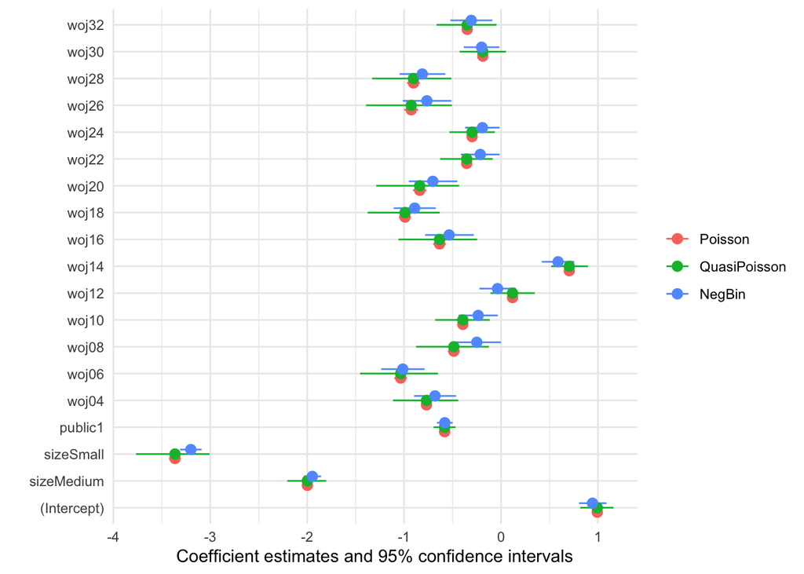

```r
modelplot(list("Poisson"=m1,"QuasiPoisson"=m2, "NegBin"=m3))
```

**Python**

**Julia**